# Reproducible Research: Peer Assessment 1

Lee Parayno

January 7, 2016

# Personal Activity Monitoring Device Analysis

## Global Options

These options will set the default location for the plots to be inside the “figure” directory.

```r
library(knitr)
opts_chunk$set(fig.path = "figure/")
```

## Loading and preprocessing the data

```r
activityFile = "activity.csv"

## Function to unzip the data file
setup <- function() {
    unzip("activity.zip")
}

if (!file.exists(activityFile)) {
    setup()
}

## Load the data file
activity = read.csv(file = activityFile)

## Create a version of the data frame with NAs removed
cleanActivity = activity[!is.na(activity$steps),]
```

## What is mean total number of steps taken per day?

Aggregate all the step values by the date of the value, by calculating the sum of the steps.

```r
## Sum all the steps by day
stepAverage <- aggregate(activity$steps, by=list(date=activity$date), FUN=sum)

names(stepAverage) = c("date","steps")

## Remove the days with no steps
stepAverage <- stepAverage[!is.na(stepAverage$steps),]

stepAverage
```

```
##          date steps
## 2  2012-10-02   126
## 3  2012-10-03 11352
## 4  2012-10-04 12116
## 5  2012-10-05 13294
## 6  2012-10-06 15420
## 7  2012-10-07 11015
## 9  2012-10-09 12811
## 10 2012-10-10  9900
## 11 2012-10-11 10304
## 12 2012-10-12 17382
## 13 2012-10-13 12426
## 14 2012-10-14 15098
## 15 2012-10-15 10139
## 16 2012-10-16 15084
```

[output cut: 39 more lines]

Histogram of total number of steps taken each day

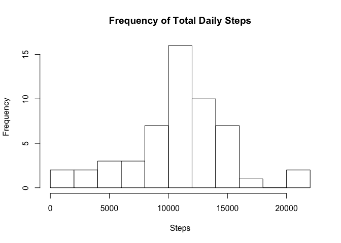

```r
hist(stepAverage$steps, breaks=10, plot = TRUE, main = "Frequency of Total Daily Steps", xlab = "Steps")
```

## What is the average daily activity pattern?

Mean steps taken per day

```r
averageSteps <- mean(stepAverage$steps)
averageSteps
```

```
## [1] 10766.19
```

Median steps taken per day

```r
medianSteps <- median(stepAverage$steps)
medianSteps
```

```
## [1] 10765
```

Mean steps per interval

```r
meanIntervalSteps <- aggregate(cleanActivity$steps, by=list(date=cleanActivity$interval), FUN=mean)
names(meanIntervalSteps) = c("interval","steps")
meanIntervalSteps <- meanIntervalSteps[!is.na(meanIntervalSteps$steps),]
meanIntervalSteps
```

```
##     interval       steps
## 1          0   1.7169811
## 2          5   0.3396226
## 3         10   0.1320755
## 4         15   0.1509434
## 5         20   0.0754717
## 6         25   2.0943396
## 7         30   0.5283019
## 8         35   0.8679245
## 9         40   0.0000000
## 10        45   1.4716981
## 11        50   0.3018868
## 12        55   0.1320755
## 13       100   0.3207547
## 14       105   0.6792453
```

[output cut: 274 more lines]

Average (Mean) Steps Per Interval

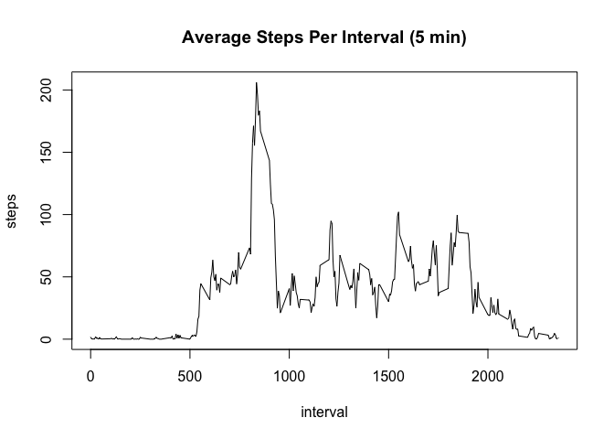

```r
plot(meanIntervalSteps, type = 'l', main = "Average Steps Per Interval (5 min)")
```

Interval with Highest Average Steps

```r
meanStepsPerInterval <- aggregate(cleanActivity$steps, by=list(date=cleanActivity$interval), FUN=mean)
names(meanStepsPerInterval) = c("interval","steps")
intervalWithHighestMeanSteps <- meanStepsPerInterval[meanStepsPerInterval$steps == max(meanStepsPerInterval$steps),]
intervalWithHighestMeanSteps
```

```
##     interval    steps
## 104      835 206.1698
```

## Imputing missing values

All the intervals where activity data was not available (NA), can be substituted with a logical replacement. The average steps in a particular interval is a reasonable substitute for missing values, as you can assume that a person would have ideally logged the average amount of steps in an interval, within a given standard deviation

```r
imputedActivity <- activity

for (i in 1:nrow(imputedActivity)) {
    if (is.na(imputedActivity[i,1])) {
        imputedActivity[i,1] <- meanStepsPerInterval[meanStepsPerInterval$interval == imputedActivity[i,3],2]
    }
}

imputedStepAverage <- aggregate(imputedActivity$steps, by=list(date=imputedActivity$date), FUN=sum)
names(imputedStepAverage) = c("date","steps")
```

Histogram of Imputed Steps

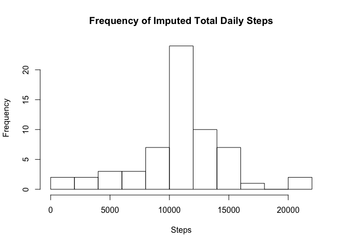

```r
#png(filename="imputed_step_average.png", width = 480, height = 480)
hist(imputedStepAverage$steps, breaks=10, plot = TRUE, main = "Frequency of Imputed Total Daily Steps", xlab = "Steps")
```

```r
#dev.off()
```

Average Steps with Imputed Values

```r
imputedAverageSteps <- mean(imputedStepAverage$steps)
imputedAverageSteps
```

```
## [1] 10766.19
```

Median Steps with Imputed Values

```r
imputedMedianSteps <- median(imputedStepAverage$steps)
imputedMedianSteps
```

```
## [1] 10766.19
```

## Are there differences in activity patterns between weekdays and weekends?

We need to determine the day of the week for each date of activity, in order to find out whether the activity was on a weekday or weekend.

Code to determine the weekday or weekend:

```r
weekdayValues <- weekdays(as.Date(imputedActivity$date))

for (i in 1:length(weekdayValues)) {
    if (weekdayValues[i] %in% c("Monday","Tuesday","Wednesday","Thursday","Friday")) {
        weekdayValues[i] <- "weekday"
    } else {
        weekdayValues[i] <- "weekend"
    }
}
imputedActivity <- cbind(imputedActivity, weekdayValues)
```

Aggregate the steps by interval and by weekday.

```r
stepsByIntervalByWeekday <- aggregate(imputedActivity$steps, by=list(interval=imputedActivity$interval, weekdayValues=imputedActivity$weekdayValues), FUN=mean)
names(stepsByIntervalByWeekday) <- c("interval", "weekdayValues","steps")
```

Plot the time series with the facets set for the weekday types of weekday and weekend.

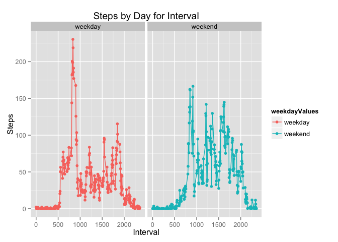

```r
library(ggplot2)

plot <- qplot(interval, steps, data = stepsByIntervalByWeekday, color = weekdayValues, facets = . ~ weekdayValues)
plot + geom_line() + labs(title = "Steps by Day for Interval") + labs(x = "Interval", y = "Steps")
```